# Tutorial 06

## Analysis of physiological data

## Slides Content

### 1. Introduction

### 2. Topic & Dataset description

### 3. Let's work!

# Introduction

### Wearable devices contain sensors

[figure not shown]

<sub><sup>Image source: empatica.com</sup></sub>

## Photoplethysmography (PPG) [1]

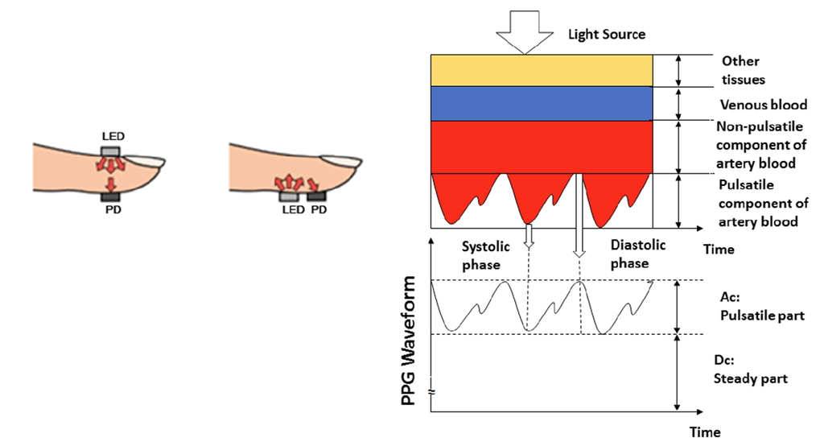

### What can you extract?

#### • Compute Blood Volume Pulse (BVP)

#### • From BVP, compute Heart Rate (HR), Heart Rate Variability (HRV) and Respiratio Rate (RR)

### What can you do?

#### • Detect high HR

#### • Stress level

#### • Physical activity

#### • Many others

## Electrodermal Activity (EDA) [2]

[output not shown]

<sub><sup>Image source: empatica.com</sup></sub>

### What can you extract?

#### • Compute EDA components

#### • *Phasic EDA - short term changes*

#### • *Tonic EDA - long term changes*

### What can you do?

#### • EDA is correlated with Autonomous Nervous System (ANS)

#### • Level of attention

#### • Cognitive load

#### • **Engagement**

# All clear? Any questions?

# Topic and Description

## Objective

## Analyse Engagement in the classroom

## How?

### • EDA data from wearable devices

### • Statistical analysis

### • Use Machine Learning 🤖 to make predictions

## Our data [3]

### • EDA from Empatica E4 device

### • Collected during lectures

### • Self-report for engagement level (high vs low)

## Why use EDA data? 🤔

# EDA ↔ Autonomous Nervous System

# All clear? Any questions?

# Hands on!

Let's install. You need a python environment with the following libraries:

- pandas
- numpy
- scipy
- neurokit2
- seaborn
- plotly
- matplotlib

You can create a new conda environment from a yaml file provided with:

```
conda env create -f environment.yml
```

### Load the EDA data.

- a timestamp, containing information regarding the timezone as well
- the EDA value. This is the raw signal recorded from the device

```python
eda_data: pd.DataFrame = pd.read_csv("./example_data_data.csv",
                                     index_col=0)
# convert the timestamp column to the correct class
eda_data['timestamp'] = pd.to_datetime(eda_data['timestamp'],
                                       format='mixed')
display(eda_data.head())
```

|  | username | timestamp | EDA |
| --- | --- | --- | --- |
| 134682 | S046 | 2017-03-07 13:33:04+01:00 | -0.000335 |
| 134683 | S046 | 2017-03-07 13:33:04.250000+01:00 | 0.171931 |
| 134684 | S046 | 2017-03-07 13:33:04.500000+01:00 | 0.287944 |
| 134685 | S046 | 2017-03-07 13:33:04.750000+01:00 | 0.347446 |
| 134686 | S046 | 2017-03-07 13:33:05+01:00 | 0.373088 |

For the moment, let's select a single user.

```python
users = eda_data['username'].unique()
user_to_select = users[0]
eda_data_subset = eda_data[
    eda_data['username'] == user_to_select
    ].copy()
```

Let's look at a few simple statistics for the EDA data.

```python
display(eda_data_subset.describe())
```

|  | EDA |
| --- | --- |
| count | 26760.000000 |
| mean | 0.396377 |
| std | 0.190366 |
| min | -0.000335 |
| 25% | 0.239891 |
| 50% | 0.371447 |
| 75% | 0.535648 |
| max | 1.700912 |

## Make a plot

We want to visualize the data. We can use `matplotlib` to see our timeseries.

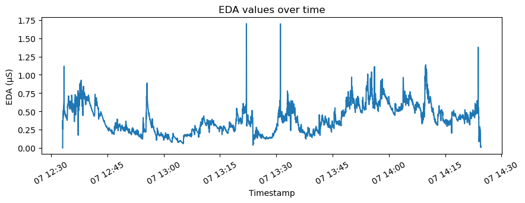

```python
plt.figure(figsize=(10,3))

plt.plot(eda_data_subset['timestamp'].values,
         eda_data_subset['EDA'].values, '-')
plt.xticks(rotation=30)
plt.xlabel("Timestamp")
plt.ylabel("EDA (μS)")
plt.title("EDA values over time")
plt.show()
```

## Filtering

The raw EDA data is not ideal to work on. This can be due to factors such as artifacts in the signals, e.g., sudden movements. As such, it is appropriate to apply some **filters**.

For EDA data, we shall apply a 1st Order Butterworth filter, with a cutoff frequency of 0.4Hz.

Why this specific filter? Researchers from the literature, in similar scenarios, have found it appropriate. Later we'll show what changes with different filters. 🤔

## Butterworth filter [4]

### • Mathematically complicated filter

### • Designed to have maintain signal strength across different frequencies

### • It maintains the "passband" (important part of the signal) unchanged as much as possible

### • We just remove the noise

```python
filtered_data: ndarray = butter_lowpass_filter_filtfilt(
                            data=eda_data_subset['EDA'],
                            fs=4,
                            cutoff=0.4,
                            order=1)
eda_data_subset['filt-EDA'] = filtered_data
```

Let's see the difference!

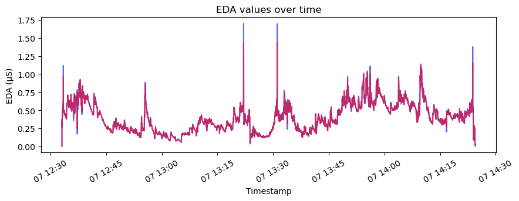

```python
plt.figure(figsize=(10,3))
plt.plot(eda_data_subset['timestamp'].values,
         eda_data_subset['EDA'].values, '-',
         color='blue', alpha=0.6)
plt.plot(eda_data_subset['timestamp'].values,
         eda_data_subset['filt-EDA'].values, '-',
         color='red', alpha=0.6)
plt.xticks(rotation=30)
plt.xlabel("Timestamp")
plt.ylabel("EDA (μS)")
plt.title("EDA values over time")
plt.show()
```

Let's see how a different cutoff might change our filtering.

```python
filtered_data: ndarray = butter_lowpass_filter_filtfilt(
                            data=eda_data_subset['EDA'],
                            fs=4,
                            cutoff=0.05,
                            order=1)
eda_data_subset['filt-EDA-2'] = filtered_data
```

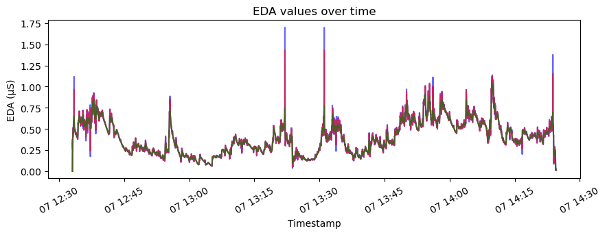

```python
plt.figure(figsize=(10,3))

plt.plot(eda_data_subset['timestamp'].values, eda_data_subset['EDA'].values, '-', color='blue', alpha=0.6)
plt.plot(eda_data_subset['timestamp'].values, eda_data_subset['filt-EDA'].values, '-', color='red', alpha=0.6)
plt.plot(eda_data_subset['timestamp'].values, eda_data_subset['filt-EDA-2'].values, '-', color='green', alpha=0.6)
plt.xticks(rotation=30)
plt.xlabel("Timestamp")
plt.ylabel("EDA (μS)")
plt.title("EDA values over time")
plt.show()
```

## Normalization

### • Different users have different responses

### • Interpersonal variability

### • How to deal with this issue?

## Normalization → remove interpersonal differences

Let's look at how the ranges differ for our users

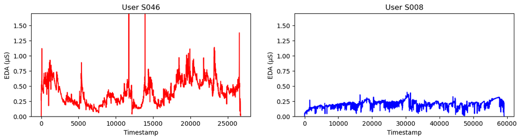

```python
fig, axs = plt.subplots(1,2, figsize=(14, 3))
total_max = max(eda_data['EDA'])
total_min = min(eda_data['EDA'])
for ax, usr, col in zip(axs,
                        list(eda_data['username'].unique()),
                        ['red', 'blue']):
    ax.plot(eda_data[eda_data['username'] == usr]['EDA'].values,
            '-', color=col)
    ax.set_xlabel("Timestamp")
    ax.set_ylabel("EDA (μS)")
    ax.set_title(f"User {usr}")
    ax.set_ylim(total_min, total_max)
plt.show()
```

Define a function to perform the normalization

```python
import numpy as np
def normalize_signals(x: np.ndarray) -> np.ndarray:
    """
    This method takes as input an array and perform the normalization (min-max) over it.

    Args:
        x (ndarray): input array

    Returns:
        (ndarray): array normalized

    """
    max_val: float = np.max(x)
    min_val: float = np.min(x)
    return (x - min_val)/(max_val - min_val)
```

The normalization has to be applied on **each** different user's data.

**But** we need to first filter the data for both users.

```python
filtered_data: ndarray = [
    butter_lowpass_filter_filtfilt(
    data=eda_data[eda_data['username'] == user]['EDA'],
    fs=4,
    cutoff=0.4,
    order=1,)
    for user in eda_data['username'].unique()]
filtered_data: np.ndarray = np.concatenate(filtered_data)
eda_data['filt-EDA'] = filtered_data
```

Now, we can apply the normalization.

Again, to each user.

```python
normalized_data: list[np.ndarray] = [
    normalize_signals(
        x=eda_data[eda_data['username'] == user]['filt-EDA'].values
    )
    for user in eda_data['username'].unique()
]
normalized_data: np.ndarray = np.concatenate(normalized_data)
eda_data['norm-EDA'] = normalized_data
```

Let's look at the changes!

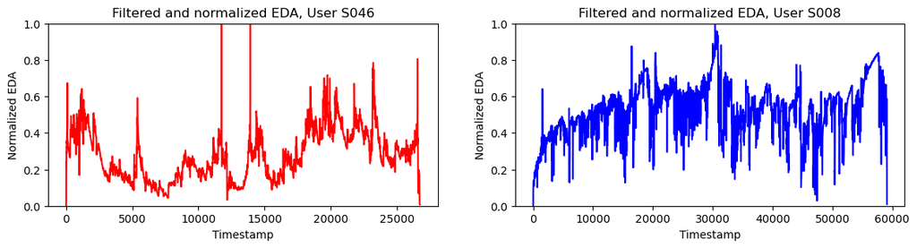

```python
fig, axs = plt.subplots(1,2, figsize=(14, 3))

total_max = max(eda_data['norm-EDA'])
total_min = min(eda_data['norm-EDA'])
for ax, usr, col in zip(axs, list(eda_data['username'].unique()),
                        ['red', 'blue']):
    ax.plot(eda_data[eda_data['username'] == usr]['norm-EDA'].values,
            '-', color=col)
    ax.set_xlabel("Timestamp")
    ax.set_ylabel("Normalized EDA")
    ax.set_title(f"Filtered and normalized EDA, User {usr}")
    ax.set_ylim(total_min, total_max)
plt.show()
```

## Feature extraction

### • Difficult to interpret the whole signal

### • Analyse only some specific "features"

### • Which features? Statistical elements: mean, std, median, etc.

### • Also, some physiological features: number of EDA peaks, peak rise time, etc.

## Do you extract features on the whole signal?

# No

### • We segment the signal into "sub-signals"

### • Length of sub-signals appropriate for task ⬅ look at the literature

First, we segment the data.

Let's consider only one user for simplicity, as before.

```python
eda_data_subset: pd.DataFrame = eda_data[
    eda_data['username'] == user_to_select
]
```

We shall use a window of 10 seconds.

The shortest EDA response is between 2 to 5 seconds. We consider longer to account for possible effects.

```python
window_size_in_sec: int = 10
spl_rate: int = 4
window_size_in_sampling_rate: int = window_size_in_sec * spl_rate
```

The sampling rate is known from the manufacturer of the device (4Hz in this case).

```python
starts: pd.Series = eda_data_subset[
                ::window_size_in_sampling_rate
            ]['timestamp']

ends: pd.Series = (starts +
                   pd.Timedelta(f"{window_size_in_sec}s") -
                   pd.Timedelta(f"{1/spl_rate}s"))
# we remove the last item since pandas will use <= by default when dealing with dates
```

We set the timestamp as the index of the DataFrame.

We do this since it is easier to slice it.

```python
eda_data_subset = eda_data_subset.set_index('timestamp')
```

```python
segmented_eda_data: list[pd.DataFrame] = [
    eda_data_subset.loc[start:end]
    for start, end in zip(starts, ends)]
# we print one example
display(segmented_eda_data[0].head(), len(segmented_eda_data[0]))
```

| timestamp | username | EDA | filt-EDA | norm-EDA |
| --- | --- | --- | --- | --- |
| 2017-03-07 13:33:04+01:00 | S046 | -0.000335 | -0.000605 | 0.000000 |
| 2017-03-07 13:33:04.250000+01:00 | S046 | 0.171931 | 0.116107 | 0.081395 |
| 2017-03-07 13:33:04.500000+01:00 | S046 | 0.287944 | 0.213103 | 0.149040 |
| 2017-03-07 13:33:04.750000+01:00 | S046 | 0.347446 | 0.281433 | 0.196693 |
| 2017-03-07 13:33:05+01:00 | S046 | 0.373088 | 0.322593 | 0.225398 |

```
40
```

We now extract features.

For the sake of this tutorial, we are going to use the following limited list:

- min
- max
- std
- mean
- number of EDA peaks

```python
from neurokit2.eda import eda_peaks
from warnings import warn

def extract_features(data: np.ndarray, sampling_rate: int) -> pd.Series:
    """
    This method extracts hand-crafted features for EDA signals.

    Args:
        data (ndarray): input array of EDA data
        sampling_rate (int): sampling rate of the EDA signal

    Returns:
        (Series): dataframe with the features extracted as indexes

    """

    min_feat: float = np.min(data)
    max_feat: float = np.max(data)
    mean_feat: float = np.mean(data)
    std_feat: float = np.std(data)

    try:
        eda_peaks_result: dict[str, Any] = eda_peaks(
                data,
                sampling_rate=sampling_rate,
            )
    except ValueError as e:
            # NOTE: sometimes, when no peaks are detected, as ValueError is thrown by the
            # neurokit2 method. We solve this in a very simplistic way
        warn(f"Could not extract EDA peaks. Reason: {e}")
        eda_peaks_result: tuple[None, dict[str, Any]] = (
                None,
                dict(SCR_Peaks=[], SCR_Amplitude=[0]),
            )
    number_of_peaks_feat: int = len(eda_peaks_result[1]["SCR_Peaks"])
    return pd.Series([min_feat,max_feat,mean_feat,std_feat,number_of_peaks_feat],
                        index=['Min', 'Max', 'Mean', 'Std', 'Num Peaks'])
```

```python
extracted_features: list[pd.Series] = [
    extract_features(data=segment['EDA'].values,
                     sampling_rate=spl_rate)
    for segment in segmented_eda_data]
extracted_features: pd.DataFrame = pd.concat(extracted_features,
                                             axis=1).T
```

[output not shown]

[output cut: 376 more lines]

[output not shown]

```python
display(extracted_features.head())
```

|  | Min | Max | Mean | Std | Num Peaks |
| --- | --- | --- | --- | --- | --- |
| 0 | -0.000335 | 0.471818 | 0.376805 | 0.092594 | 3.0 |
| 1 | 0.472966 | 0.616837 | 0.556352 | 0.045064 | 2.0 |
| 2 | 0.478007 | 1.118437 | 0.601757 | 0.171620 | 1.0 |
| 3 | 0.458174 | 0.499045 | 0.478604 | 0.011125 | 1.0 |
| 4 | 0.434330 | 0.458463 | 0.445287 | 0.008797 | 2.0 |

We analyse the **distribution** of the features.

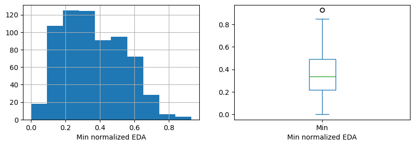

```python
fig, axs = plt.subplots(1,2, figsize=(10,3))
extracted_features['Min'].hist(ax=axs[0])
extracted_features['Min'].plot.box(ax=axs[1])
for ax in axs:
    ax.set_xlabel('Min normalized EDA')
plt.show()
```

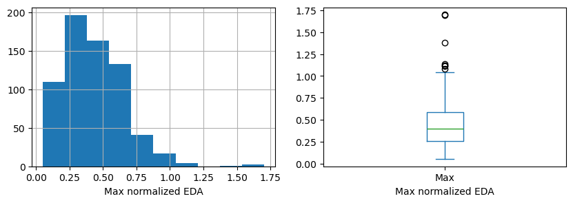

```python
fig, axs = plt.subplots(1,2, figsize=(10,3))
extracted_features['Max'].hist(ax=axs[0])
extracted_features['Max'].plot.box(ax=axs[1])
for ax in axs:
    ax.set_xlabel('Max normalized EDA')
plt.show()
```

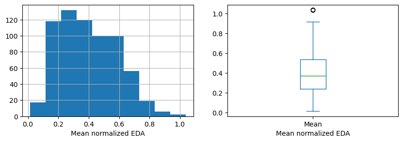

```python
fig, axs = plt.subplots(1,2, figsize=(10,3))
extracted_features['Mean'].hist(ax=axs[0])
extracted_features['Mean'].plot.box(ax=axs[1])
for ax in axs:
    ax.set_xlabel('Mean normalized EDA')
plt.show()
```

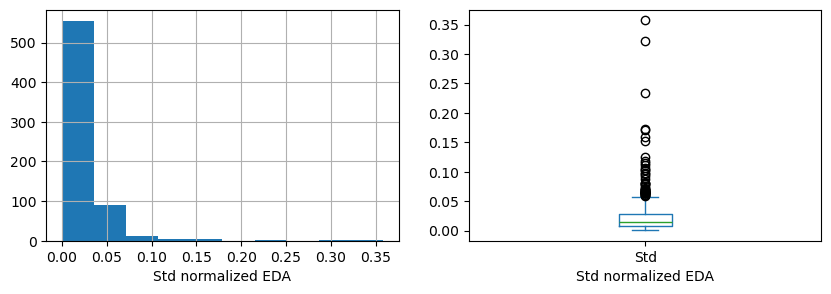

```python
fig, axs = plt.subplots(1,2, figsize=(10,3))
extracted_features['Std'].hist(ax=axs[0])
extracted_features['Std'].plot.box(ax=axs[1])
for ax in axs:
    ax.set_xlabel('Std normalized EDA')
plt.show()
```

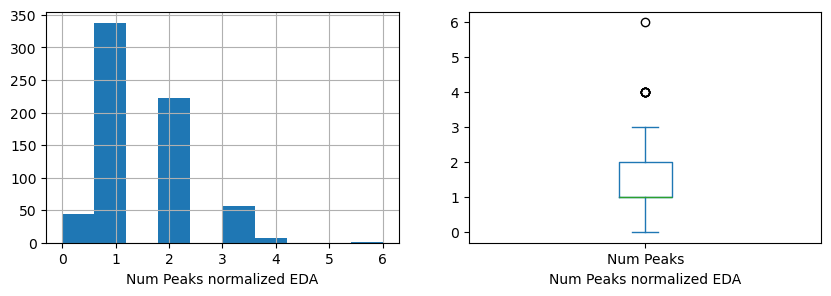

```python
fig, axs = plt.subplots(1,2, figsize=(10,3))
extracted_features['Num Peaks'].hist(ax=axs[0])
extracted_features['Num Peaks'].plot.box(ax=axs[1])
for ax in axs:
    ax.set_xlabel('Num Peaks normalized EDA')
plt.show()
```

# How do the features differ based on engagement?

We can find the engagement information in a separate table.

```python
engagement_info = pd.read_csv("./example_user_info_data.csv",
                              index_col=0)
```

```python
display(engagement_info.head())
```

|  | username | date | engagement | start | end |
| --- | --- | --- | --- | --- | --- |
| 0 | S001 | 27Feb | 1 | 2017-02-27 09:33:00+01:00 | 2017-02-27 10:11:00+01:00 |
| 1 | S001 | 27Feb | 1 | 2017-02-27 08:32:00+01:00 | 2017-02-27 09:19:00+01:00 |
| 2 | S001 | 27Feb | 1 | 2017-02-27 11:31:00+01:00 | 2017-02-27 12:19:00+01:00 |
| 3 | S001 | 27Feb | 1 | 2017-02-27 10:30:00+01:00 | 2017-02-27 11:16:00+01:00 |
| 4 | S001 | 8March | 1 | 2017-03-08 11:33:00+01:00 | 2017-03-08 12:16:00+01:00 |

Let's consider only our selected user's data.

We will re-segment the data and figure out which engagement label (1="engaged" or 0="not engaged") to apply.

```python
engagement_info_subset = engagement_info[
    engagement_info['username'] == user_to_select
].copy()
engagement_info_subset['start'] = pd.to_datetime(
    engagement_info_subset['start']
)
engagement_info_subset['end'] = pd.to_datetime(
    engagement_info_subset['end']
)
```

```python
def segmentation_with_label(eda_data: pd.DataFrame,
                            start: pd.Timestamp,
                            end: pd.Timestamp,
                            label_df: pd.DataFrame) -> tuple[pd.DataFrame, int | float]:
    segment: pd.DataFrame = eda_data_subset.loc[start:end]
#         Due to the construction of the info dataframe, we have to iterate through all of the rows
# However, only one row will match the timestamps
    engagement_labels: list[int] = [
        row['engagement']
        for _, row in engagement_info_subset.iterrows()
        if (start >= row["start"]) and (end <= row["end"])]
    if len(engagement_labels) > 1:
        raise RuntimeError(f'Two rows of the info dataframes match the given segment')
    elif len(engagement_labels) == 0:
        label: float = np.nan
    else:
        label: int = engagement_labels[0]
    return segment, label

segmented_eda_data: list[pd.DataFrame] = [segmentation_with_label(
    eda_data_subset,
    start,
    end,
    label_df=engagement_info_subset)
                                          for start, end in zip(starts,
                                                                ends)]
```

```python
# we split them to reuse our previous functions
labels: list[int | float] = [el[1] for el in segmented_eda_data]
segmented_eda_data: list[pd.DataFrame] = [el[0]
                                          for el in segmented_eda_data]
```

```python
extracted_features: list[pd.Series] = [extract_features(
    data=segment['EDA'].values,
    sampling_rate=spl_rate)
                                       for segment in segmented_eda_data]
extracted_features: pd.DataFrame = pd.concat(extracted_features,
                                             axis=1).T
```

[output not shown]

[output cut: 376 more lines]

[output not shown]

```python
display(extracted_features.head())
```

|  | Min | Max | Mean | Std | Num Peaks |
| --- | --- | --- | --- | --- | --- |
| 0 | -0.000335 | 0.471818 | 0.376805 | 0.092594 | 3.0 |
| 1 | 0.472966 | 0.616837 | 0.556352 | 0.045064 | 2.0 |
| 2 | 0.478007 | 1.118437 | 0.601757 | 0.171620 | 1.0 |
| 3 | 0.458174 | 0.499045 | 0.478604 | 0.011125 | 1.0 |
| 4 | 0.434330 | 0.458463 | 0.445287 | 0.008797 | 2.0 |

```python
extracted_features['engagement'] = labels
extracted_features = extracted_features.dropna(how='any',
                                               subset=['engagement'])
```

```python
display(extracted_features.head())
```

|  | Min | Max | Mean | Std | Num Peaks | engagement |
| --- | --- | --- | --- | --- | --- | --- |
| 12 | 0.549102 | 0.639706 | 0.598076 | 0.025608 | 2.0 | 0.0 |
| 13 | 0.527328 | 0.614816 | 0.574748 | 0.020174 | 1.0 | 0.0 |
| 14 | 0.582498 | 0.720007 | 0.677338 | 0.044795 | 2.0 | 0.0 |
| 15 | 0.485569 | 0.656319 | 0.531213 | 0.053632 | 2.0 | 0.0 |
| 16 | 0.496413 | 0.607636 | 0.568246 | 0.041843 | 1.0 | 0.0 |

Finally, we can show the distribution as before. In this case, we separate depending on the engagement level.

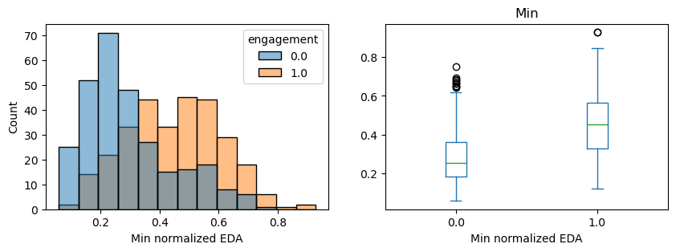

```python
import seaborn as sns
fig, axs = plt.subplots(1,2, figsize=(10,3))
sns.histplot(ax=axs[0], data=extracted_features, x='Min',
             hue='engagement')
extracted_features.plot.box(ax=axs[1],
                            column='Min',
                            by='engagement')
for ax in axs:
    ax.set_xlabel('Min normalized EDA')
plt.show()
```

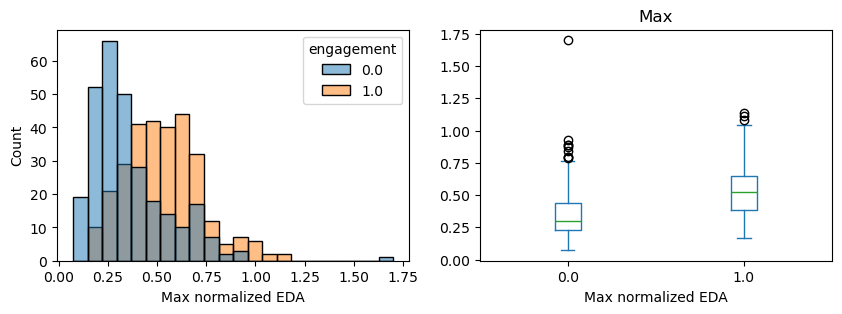

```python
import seaborn as sns

fig, axs = plt.subplots(1,2, figsize=(10,3))

sns.histplot(ax=axs[0], data=extracted_features,
             x='Max', hue='engagement')
extracted_features.plot.box(ax=axs[1],
                            column='Max', by='engagement')
for ax in axs:
    ax.set_xlabel('Max normalized EDA')
plt.show()
```

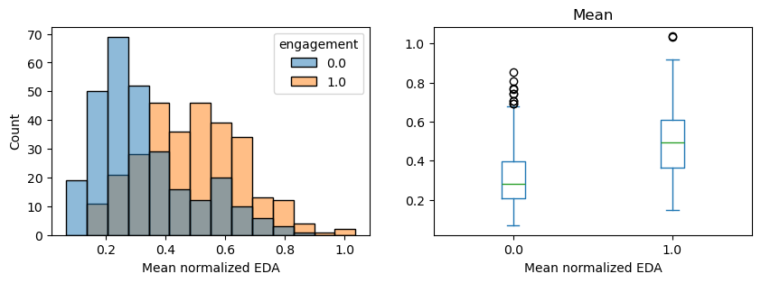

```python
import seaborn as sns

fig, axs = plt.subplots(1,2, figsize=(10,3))

sns.histplot(ax=axs[0], data=extracted_features,
             x='Mean', hue='engagement')
extracted_features.plot.box(ax=axs[1],
                            column='Mean', by='engagement')
for ax in axs:
    ax.set_xlabel('Mean normalized EDA')
plt.show()
```

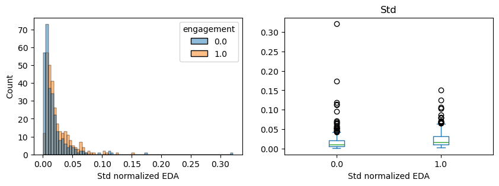

```python
import seaborn as sns

fig, axs = plt.subplots(1,2, figsize=(10,3))

sns.histplot(ax=axs[0], data=extracted_features,
             x='Std', hue='engagement')
extracted_features.plot.box(ax=axs[1],
                            column='Std', by='engagement')
for ax in axs:
    ax.set_xlabel('Std normalized EDA')
plt.show()
```

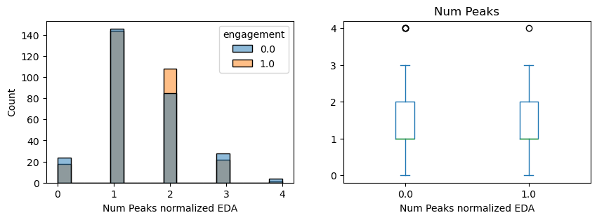

```python
import seaborn as sns

fig, axs = plt.subplots(1,2, figsize=(10,3))

sns.histplot(ax=axs[0], data=extracted_features,
             x='Num Peaks', hue='engagement')
extracted_features.plot.box(ax=axs[1],
                            column='Num Peaks', by='engagement')
for ax in axs:
    ax.set_xlabel('Num Peaks normalized EDA')
plt.show()
```

# Any questions?

[figure not shown]

# References

[1] Ismail, S., Akram, U. and Siddiqi, I., 2021. Heart rate tracking in photoplethysmography signals affected by motion artifacts: A review. EURASIP Journal on Advances in Signal Processing, 2021(1), pp.1-27.

[2] Boucsein, W., 2012. Electrodermal activity. Springer Science & Business Media.

[3] Di Lascio, E., Gashi, S. and Santini, S., 2018. Unobtrusive assessment of students' emotional engagement during lectures using electrodermal activity sensors. Proceedings of the ACM on Interactive, Mobile, Wearable and Ubiquitous Technologies, 2(3), pp.1-21.

[4] Butterworth, S., 1930. On the theory of filter amplifiers. Wireless Engineer, 7(6), pp.536-541.